# Quiz

Levon Khachatryan

2018 11 16

First of all we should install and import the appropriate libraries with these commands:

```r
if (!require(wooldridge)) { install.packages("wooldridge"); library(wooldridge) }
attach(wage2)
```

The type of above mentioned dataset is

```r
class(wage2)
```

```
## [1] "data.frame"
```

## 1

Estimate the simple regression model: $\log(wage) = \beta_{0} + \beta_{1}educ + \upsilon$

```r
y <- lwage
x <- educ
xbar <- mean(x)
ybar <- mean(y)
model1 <- lm(y ~ x)
model_summary <- summary(model1)
model_summary
```

```
##
## Call:
## lm(formula = y ~ x)
##
## Residuals:
##      Min       1Q   Median       3Q      Max
## -1.94620 -0.24832  0.03507  0.27440  1.28106
##
## Coefficients:
##             Estimate Std. Error t value Pr(>|t|)
## (Intercept) 5.973063   0.081374   73.40   <2e-16 ***
## x           0.059839   0.005963   10.04   <2e-16 ***
## ---
## Signif. codes:  0 '***' 0.001 '**' 0.01 '*' 0.05 '.' 0.1 ' ' 1
##
## Residual standard error: 0.4003 on 933 degrees of freedom
## Multiple R-squared:  0.09742,    Adjusted R-squared:  0.09645
## F-statistic: 100.7 on 1 and 933 DF,  p-value: < 2.2e-16
```

Let’s plot the line of linear regression and scatter plot

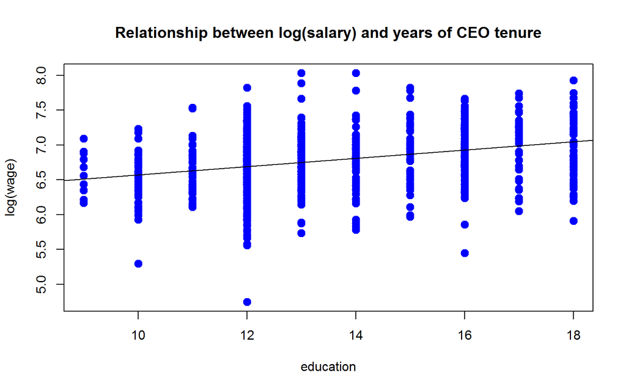

```r
par(mfrow=c(1,1))
plot(y ~ x , data = wage2, col='blue', pch=20, cex=2, main="Relationship between log(salary) and years of CEO tenure",
    xlab="education", ylab="log(wage)")
abline(model1)
```

Based on this regression calculate (x=educ, y=log(wage))  
$\beta_{1} = \frac{\sum_{i=1}^{n}(x_{i}-\overline{x})(y_{i}-\overline{y})}{\sum_{i=1}^{n}(x_{i}-\overline{x})^2}$  
and show that it consistent with results of lm function in R.

```r
b1.hat <- (sum((x - xbar)*(y - ybar)))/sum((x - xbar)^2)
b1.hat
```

```
## [1] 0.0598392
```

Or as we know this is the same as

```r
b1.hat_1 <- cov(x , y) / var(x)
b1.hat_1
```

```
## [1] 0.0598392
```

Lets check if our value is consisten with lm value

```r
model_summary$coefficients
```

```
##              Estimate  Std. Error  t value    Pr(>|t|)
## (Intercept) 5.9730625 0.081373684 73.40288 0.00000e+00
## x           0.0598392 0.005963094 10.03492 1.42287e-22
```

```r
if ( all.equal(model_summary$coefficients[2,1], b1.hat) == TRUE){
  print("It is consistent with results of lm function ")
} else {
  print("It is not consistent with result of lm function ")
}
```

```
## [1] "It is consistent with results of lm function "
```

*all.equal(x, y) is a utility to compare R objects x and y testing ‘near equality’*

## 2

Based on this regression calculate standard error of slope (x=educ, y=log(wage))  
$SE(\beta_{1})=s \sqrt{\frac{n}{(n\sum_{}^{} (x^2)- (\sum_{}^{} x)^2)}}$  
Where  
$s^{2}=\frac{\sum_{i=1}^{n} (y_{i}-\hat{y}_{i})^2}{n-2}$  
and show that it consistent with results of lm function in R.

```r
b0.hat <- ybar - b1.hat * xbar
n <- length(y)
yfit <- b0.hat + b1.hat * x
e <- y - yfit
sig.hat <- sqrt(sum(e^2)/(n-2))

SE_b1 <- sig.hat*( sqrt( n / (n*sum(x^2) - sum(x)^2 )))
SE_b1
```

```
## [1] 0.005963094
```

and about consistency

```r
if ( all.equal(model_summary$coefficients[2,2], SE_b1) == TRUE){
  print("It is consistent with results of lm function ")
} else {
  print("It is not consistent with result of lm function ")
}
```

```
## [1] "It is consistent with results of lm function "
```

## 3

```r
SST <- sum((y-ybar)^2)
SSR <- sum((y-yfit)^2)
R_squared <- (SST-SSR)/SST
```

And finally I am showing that this result is consistent with result of lm function

```r
if ( all.equal(model_summary$r.squared, R_squared) == TRUE){
  print("It is consistent with results of lm function ")
} else {
  print("It is not consistent with result of lm function ")
}
```

```
## [1] "It is consistent with results of lm function "
```

## 4

Estimate the model in which log(wage) is dependent variable and all others variables in data set are independent. Add the variables exper^ 2 and tenure^2 to the equation as independent variables. Compute stepwise regression (“backward”) and report the results in the usual form. Comment on the five most important regression results:  
There are many functions and R packages for computing stepwise regression. These include: stepAIC() [MASS package], which choose the best model by AIC. It has an option named direction, which can take the following values: i) “both” (for stepwise regression, both forward and backward selection); “backward” (for backward selection) and “forward” (for forward selection). It return the best final model.  
But first of all we should replace nullable values

```r
library(DMwR)
if( anyNA(wage2)) {

  wage2 <- knnImputation(wage2)  # missing value treatment

}
```

Now as our dataset has not nullable values , we can work with model

```r
if (!require(MASS)) { install.packages("MASS"); library(MASS) }
library(MASS)
# Fit the full model
full.model <- lm( y~., data = wage2)
added.model <- update(full.model, formula = . ~ . + I(exper^2) + I(tenure^2) - wage)
summary(added.model)
```

```
##
## Call:
## lm(formula = y ~ hours + IQ + KWW + educ + exper + tenure + age +
##     married + black + south + urban + sibs + brthord + meduc +
##     feduc + lwage + I(exper^2) + I(tenure^2), data = wage2)
##
## Residuals:
##        Min         1Q     Median         3Q        Max
## -7.071e-16 -4.120e-17 -1.080e-17  1.710e-17  1.217e-14
##
## Coefficients:
##               Estimate Std. Error    t value Pr(>|t|)
## (Intercept) -5.828e-15  3.127e-16 -1.864e+01  < 2e-16 ***
## hours        6.078e-18  1.885e-18  3.224e+00  0.00131 **
## IQ          -3.584e-18  1.170e-18 -3.064e+00  0.00225 **
## KWW         -1.675e-18  2.300e-18 -7.280e-01  0.46672
## educ        -4.878e-17  8.906e-18 -5.477e+00 5.59e-08 ***
## exper       -1.112e-17  1.431e-17 -7.770e-01  0.43728
## tenure      -2.087e-18  9.211e-18 -2.270e-01  0.82078
## age         -6.250e-18  6.113e-18 -1.022e+00  0.30684
## married     -2.228e-16  4.436e-17 -5.023e+00 6.11e-07 ***
## black        1.480e-16  4.674e-17  3.167e+00  0.00159 **
## south        7.126e-17  2.998e-17  2.377e+00  0.01767 *
## urban       -1.969e-16  3.110e-17 -6.331e+00 3.81e-10 ***
## sibs        -9.786e-18  7.692e-18 -1.272e+00  0.20365
## brthord      1.715e-17  1.100e-17  1.559e+00  0.11931
## meduc       -5.959e-18  6.184e-18 -9.640e-01  0.33548
## feduc       -9.398e-18  5.746e-18 -1.635e+00  0.10231
## lwage        1.000e+00  3.748e-17  2.668e+16  < 2e-16 ***
## I(exper^2)   2.426e-20  6.284e-19  3.900e-02  0.96921
## I(tenure^2) -5.911e-19  5.367e-19 -1.101e+00  0.27099
## ---
## Signif. codes:  0 '***' 0.001 '**' 0.01 '*' 0.05 '.' 0.1 ' ' 1
##
## Residual standard error: 4.067e-16 on 916 degrees of freedom
## Multiple R-squared:      1,  Adjusted R-squared:      1
## F-statistic: 5.565e+31 on 18 and 916 DF,  p-value: < 2.2e-16
```

```r
# Stepwise regression model
step.model <- stepAIC(added.model, direction = "backward", trace=FALSE)
summary(step.model)
```

```
##
## Call:
## lm(formula = y ~ hours + KWW + educ + exper + tenure + age +
##     married + black + south + brthord + meduc + feduc + lwage +
##     I(exper^2), data = wage2)
##
## Residuals:
##        Min         1Q     Median         3Q        Max
## -9.777e-17 -4.828e-18  3.200e-20  4.116e-18  1.650e-16
##
## Coefficients:
##               Estimate Std. Error    t value Pr(>|t|)
## (Intercept)  4.715e-17  1.249e-17  3.775e+00  0.00017 ***
## hours       -4.438e-20  7.806e-20 -5.690e-01  0.56982
## KWW          2.815e-19  9.133e-20  3.082e+00  0.00212 **
## educ        -2.051e-18  3.485e-19 -5.884e+00  5.6e-09 ***
## exper       -1.854e-18  5.928e-19 -3.127e+00  0.00182 **
## tenure       1.214e-20  1.161e-19  1.050e-01  0.91671
## age         -1.901e-19  2.461e-19 -7.720e-01  0.44005
## married      0.000e+00  1.834e-18  0.000e+00  1.00000
## black        0.000e+00  1.811e-18  0.000e+00  1.00000
## south        0.000e+00  1.227e-18  0.000e+00  1.00000
## brthord      0.000e+00  3.792e-19  0.000e+00  1.00000
## meduc        0.000e+00  2.553e-19  0.000e+00  1.00000
## feduc        0.000e+00  2.375e-19  0.000e+00  1.00000
## lwage        1.000e+00  1.507e-18  6.637e+17  < 2e-16 ***
## I(exper^2)   5.228e-20  2.602e-20  2.009e+00  0.04482 *
## ---
## Signif. codes:  0 '***' 0.001 '**' 0.01 '*' 0.05 '.' 0.1 ' ' 1
##
## Residual standard error: 1.686e-17 on 920 degrees of freedom
## Multiple R-squared:      1,  Adjusted R-squared:      1
## F-statistic: 4.162e+34 on 14 and 920 DF,  p-value: < 2.2e-16
```

```r
AIC(added.model)
```

```
## [1] -63595.88
```

```r
AIC(step.model)
```

```
## [1] -69551.89
```

AIC=2k-2Ln(L) BIC=ln(n)k-2ln(L)

the train() function [caret package] provides an easy workflow to perform stepwise selections using the leaps and the MASS packages. It has an option named method, which can take the following values:

“leapBackward”, to fit linear regression with backward selection “leapForward”, to fit linear regression with forward selection “leapSeq”, to fit linear regression with stepwise selection . You also need to specify the tuning parameter nvmax, which corresponds to the maximum number of predictors to be incorporated in the model.

For example, you can vary nvmax from 1 to 5. In this case, the function starts by searching different best models of different size, up to the best 5-variables model. That is, it searches the best 1-variable model, the best 2-variables model, ., the best 5-variables models.